# The 2017-2025 mining product: how it is built, and how good it is

Till Meissner

2026-11-25

# Summary

**What this is.** For 2017-2025 we map mining every year directly, from Google’s annual satellite embeddings, with a classifier trained on existing mining maps. This report covers how the annual maps are built, how a temporal rule cleans their year-to-year flicker, and what we know about their accuracy. The years before 2017 are dated separately by backdating (see `diag_04_backdating_report`).

- **Conservative by design:** at the deployed cutoff (70), 95% of the points the classifier calls mining are mining (user’s accuracy), but it finds only 65% of true mines (producer’s accuracy). SmallMinesDS 2022, gold belt only (Section 2).
- **Two definitions of “mined”**, both from one temporal rule (Section 1.3): by 2025, 2071 km² have *ever* been mined (Option 1, main spec), and 1824 km² are *currently* mined (Option 2). The raw 2025 mask shows 1824 km².
- **Artisanal and small-scale mining only:** the classifier maps all mining. The footprints of 14 named industrial mines (ICMM, outlined with Maus et al. / Tang & Werner) are removed in every year (Section 1.2).
- **What the rule fixes, and what it doesn’t:** it removes one-year blips and fills one-year gaps. It cannot remove false positives that persist for two years or more, recover missed mines, or tell a real one-year mine from a blip (Section 5).
- **No reference product is ground truth.** Agreement with Barenblitt et al., Maus et al. and Tang & Werner is triangulation, not accuracy (Section 3).

# 1. Methods

## 1.1 From embeddings to an annual mask

**Why cutoff 70**

## 1.2 Separating artisanal from industrial mining

The research target is galamsey, i.e. artisanal and small-scale mining. The classifier itself cannot tell the two apart. Barenblitt et al.’s positives are filtered to artisanal sites, but Tang & Werner’s have no type field, and a pit looks much the same in either case. So the classifier maps *all* mining, and the large-scale operations are removed afterwards, as fixed footprints.

1. **Locate** the industrial mines with the ICMM global mining dataset: named sites reported by member companies, as points. This gives 14 mines in Ghana: Ahafo, Obuasi, Tarkwa, Chirano, Bibiani, Damang, Wassa, Edikan, Iduapriem, Akyem, Asanko (Obotan), Bogoso-Prestea, Prestea and Awaso.
2. **Outline** each mine with polygons from Maus et al. (2022, v2) near the point. At three mines (Edikan, Asanko Obotan, Prestea), Maus’s polygon is implausibly large (100-300 km² for one mine), so Tang & Werner’s polygons are used instead.
3. **Select** the polygons per mine, after a visual check of all 14 in high-resolution imagery:
   - 8 mines: all polygons within 4 km of the point;
   - Obuasi and Awaso: within 1 km;
   - Prestea and Bogoso-Prestea: only the polygon touching the point;
   - Edikan and Asanko Obotan: the touching polygon plus its direct neighbours.
4. **Remove** the resulting footprint from every year’s mask. The footprint does not change over time.

**What this means for the numbers**

- **Artisanal mining inside or right next to an industrial footprint is removed with it**, for example galamsey on the edges of Obuasi or Prestea concessions. An earlier version subtracted Barenblitt et al.’s artisanal polygons from the footprint to protect such sites. It was dropped in favour of the per-mine visual check, because their polygons would have punched noisy holes into otherwise clean outlines.
- **Industrial mines missing from ICMM stay in the product.** ICMM is self-reported, so it is not necessarily complete, and the Minerals Commission lease map could not be used because its geometries are broken.
- **Fixed footprints:** an industrial mine that expands after its outline was mapped (~2019-2021) leaks the new area into the product.
- **The reference maps include industrial mining.** Section 3 removes the same footprint from them before comparing.

## 1.3 The temporal rule

The raw annual masks flicker: a pixel can read mine, not mine, mine. Summing first detections then over-counts, because every one-year false positive becomes “mining”. We apply **Rule B**, which only changes a pixel’s status when two consecutive years agree:

- if year T and T+1 both say mine, the pixel is mined in T;
- if both say not mine, it is not;
- if they disagree, it keeps last year’s status.

This gives two definitions:

- **Option 1, “ever mined”** (main spec): mined from the first Rule-B year on, and never exits. It uses the same definition as the backdated pre-2017 layer, which cannot observe exits either, so the 2000-2025 panel uses this one.
- **Option 2, “currently mined”**: the Rule-B status itself. It can exit, but only after two years of “not mine” in a row. It applies to 2017+ only, for questions about active mining or reclamation.

| Pixel | Raw (2017-2021) | Option 2 | Option 1 |
| --- | --- | --- | --- |
| steady mine | 1 1 1 1 1 | 1 1 1 1 1 | 1 1 1 1 1 |
| flicker | 1 1 0 1 1 | 1 1 **1** 1 1 | 1 1 **1** 1 1 |
| one-year blip | 0 0 1 0 0 | 0 0 **0** 0 0 | 0 0 **0** 0 0 |
| abandoned | 1 1 1 0 0 | 1 1 1 0 0 | 1 1 1 **1 1** |

**Edge years, and why Rule B**

- **2017** has no earlier status to carry, so it is *confirmed*: mined only if 2017 and 2018 both say mine. This is also the anchor the backdating dates from, so one-off 2017 blips get no pre-2017 onset year.
- **2025** has no 2026 to confirm against and is left raw. Option 1 entries in 2025 are therefore unconfirmed and flagged (`unconf_ha` in the panel).
- **Why Rule B:** `notes/archive/diag_03_temporal_consistency.R` compared three rules. A centred majority vote (A) smooths about as well but created an artificial dip at 2017-18. A sticky-exit rule (C) never removes blips. Rule B, forward-only, avoids both problems.

# 2. Accuracy against SmallMinesDS 2022

SmallMinesDS is an independent, hand-labelled dataset of small mines and non-mines for 2022, in the Amansie-Bekwai-Obuasi gold belt. It is the only reference we have that labels both mines and non-mines, so it is the only one we can compute producer’s and user’s accuracy from. Two limits apply: it covers one year and one area, and the gold belt is where mining is easiest to see.

- **Producer’s accuracy (PA)** = recall: of the true mines, how many do we find?
- **User’s accuracy (UA)** = precision: of what we call mining, how much is real?

## 2.1 The classifier, by cutoff

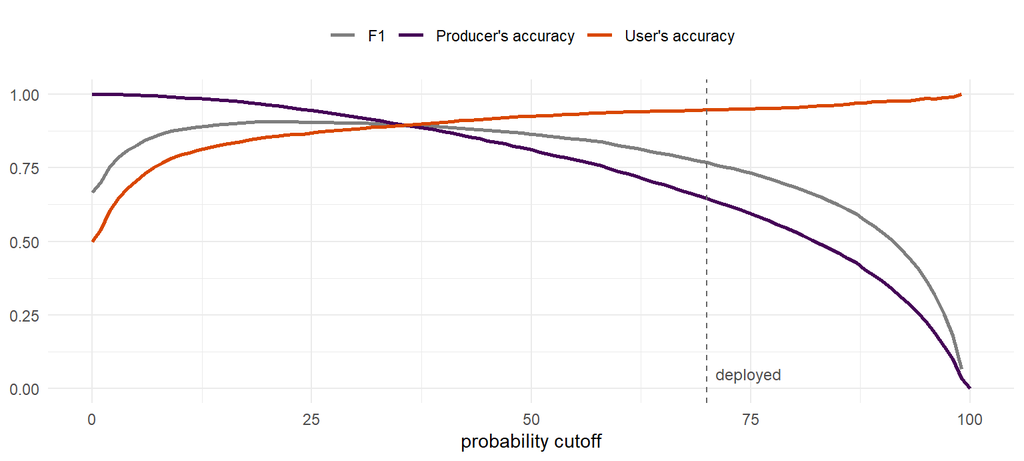

Script: `diag_02_scoring.R` (Part 3) · balanced points, 50% mines · classifier probability only, before the clean-up steps and the temporal rule

**Show table**

| cutoff | note | PA | UA | F1 |
| --- | --- | --- | --- | --- |
| 22 | best F1 | 0.956 | 0.862 | 0.906 |
| 45 | previous setting | 0.842 | 0.915 | 0.877 |
| 70 | deployed | 0.646 | 0.946 | 0.768 |
| 80 |  | 0.533 | 0.955 | 0.684 |

## 2.2 The final product, with and without the temporal rule

The same points, scored on the 2022 masks after the clean-up steps: the raw mask, and Options 1 and 2.

11,040 points (6,770 mines, 4,270 non-mines); UA on a balanced subsample (mines downsampled to 4,270), matching 2.1

| 2022 mask | producer’s accuracy | user’s accuracy |
| --- | --- | --- |
| raw masks (no rule) | 0.635 | 0.951 |
| Option 2: currently mined | 0.637 | 0.947 |
| Option 1: ever mined | 0.688 | 0.939 |

## 2.3 Which training labels

**Show table: label-source ablation, 4-class scheme**

| training positives | PA | UA | F1 | kappa |
| --- | --- | --- | --- | --- |
| barenblitt | 0.839 | 0.925 | 0.880 | 0.761 |
| maus | 0.944 | 0.782 | 0.855 | 0.671 |
| tang | 0.864 | 0.907 | 0.885 | 0.764 |
| human | 0.916 | 0.840 | 0.876 | 0.732 |
| all | 0.899 | 0.861 | 0.880 | 0.754 |
| no_maus | 0.870 | 0.907 | 0.888 | 0.781 |

# 3. Agreement with other mining maps

None of these maps is ground truth. They are model outputs or manual delineations, each with its own omissions, so we use them for triangulation:

- **Barenblitt et al. (2021):** Landsat-based random forest, SW Ghana only, 2019. Their own PA is 75.6%, so they miss about one in four mines. The only one with an artisanal/industrial split.
- **Maus et al. (2022, v2):** global manual delineation of mining land use. It is biased towards industrial mines.
- **Tang & Werner (2023):** global deep-learning map from high-resolution imagery.

To match our product, all references are shown with the industrial footprint removed. Each is compared with our mask for its imagery year, which predates its publication year: Barenblitt et al. and Maus et al. are 2019, and Tang & Werner is mixed 2019-2022, so 2021 (the same dating `build_01` uses for training labels). Tang & Werner is also shown against 2019.

| region | reference | our year | reference km² | ours km² | both km² | share of reference we also map (%) | share of ours the reference also maps (%) |
| --- | --- | --- | --- | --- | --- | --- | --- |
| All of Ghana | Maus et al. | 2019 | 1700 | 730 | 569 | 33.5 | 78.0 |
| All of Ghana | Tang & Werner | 2019 | 749 | 730 | 443 | 59.1 | 60.7 |
| All of Ghana | Tang & Werner | 2021 | 749 | 1036 | 502 | 67.1 | 48.5 |
| Barenblitt et al. study area | Barenblitt et al., all | 2019 | 299 | 720 | 270 | 90.5 | 37.6 |
| Barenblitt et al. study area | Barenblitt et al., artisanal | 2019 | 291 | 720 | 265 | 90.9 | 36.8 |
| Barenblitt et al. study area | Maus et al. | 2019 | 1695 | 720 | 569 | 33.6 | 79.0 |
| Barenblitt et al. study area | Tang & Werner | 2019 | 749 | 720 | 443 | 59.1 | 61.5 |
| Barenblitt et al. study area | Tang & Werner | 2021 | 749 | 1019 | 502 | 67.1 | 49.3 |

Ours = Option 1 (ever mined). Option 2 and raw versions are in `diag03_areas.csv` (`both_cur_*`, `both_raw_*`).

**Reading it:** a low share of the reference that we also map is expected for Maus et al. (industrial bias) and partly reflects our conservative cutoff (PA ≈ 0.65). A low share of ours that the reference also maps can mean false positives *or* artisanal sites the reference misses. Only the visual checks in `validate_finalproduct.js` can tell these apart.

# 4. Over time

## 4.1 Mined area by year

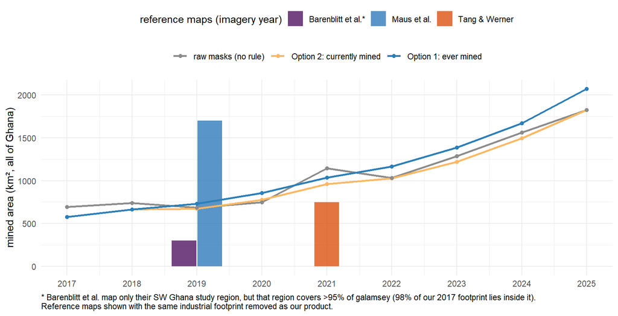

Script: `diag_03_embedding_product.R` · native 10 m

**Show table**

| year | raw masks (no rule) | Option 2: currently mined | Option 1: ever mined |
| --- | --- | --- | --- |
| 2017 | 692 | 577 | 577 |
| 2018 | 741 | 663 | 663 |
| 2019 | 684 | 670 | 730 |
| 2020 | 748 | 776 | 856 |
| 2021 | 1146 | 958 | 1036 |
| 2022 | 1032 | 1027 | 1167 |
| 2023 | 1284 | 1220 | 1388 |
| 2024 | 1563 | 1493 | 1673 |
| 2025 | 1824 | 1824 | 2071 |

Unconfirmed Option 1 entries in 2025: 399 km² (Ghana).

**Reading it:**

- **Option 1** can only rise.
- **Option 2** should rise with fewer, smaller dips than the raw series. A dip that survives Rule B means pixels that read “not mine” for two years running: abandonment, revegetation or flooding, not noise.
- **Gap between Options 1 and 2:** the area that was mined and is no longer.
- **Raw vs Option 2:** the flicker the rule removed.

## 4.2 How much the masks flicker

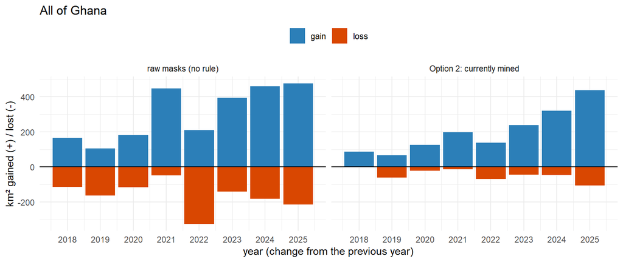

**On/off switches per pixel, 2017-2025** (share of all area ever flagged in that series, Ghana):

| series | 0 | 1 | 2 | 3 | 4+ |
| --- | --- | --- | --- | --- | --- |
| Option 2: currently mined | 21.5 | 64.5 | 11.9 | 2.1 | 0.1 |
| raw masks (no rule) | 14.9 | 44.4 | 23.9 | 10.0 | 6.8 |

0 switches = mined in every year from first detection to 2025 (or in all years). 1 = entered (or exited) once. 2 or more = flicker or re-entry.

## 4.3 The edge years

- **2017→18:** raw +49 km², Option 2 +86 km². 2017 is confirmed against 2018, so it should no longer be inflated relative to 2018 (the tested version left 2017 raw, which flattened 2017→18 to about −1 km²).
- **2024→25:** raw +261 km², Option 2 +330 km². 2025 is left raw, so a jump here is partly unconfirmed blips.

# 5. Weak spots

- **Missed mines.** At cutoff 70 we find about two thirds of true mines in the gold belt. The rule cannot add pixels, so it cannot fix this. Mined area is a lower bound.
- **Persistent false positives.** A non-mine flagged two years running passes Rule B. The known sources are bare farmland, quarries, construction and riverbanks. The September breakdown (`fp_source_breakdown_2022.csv`) was done at cutoff 45 and needs re-running at 70.
- **Real one-year mines are erased** together with blips, because they look identical.
- **Industrial-only areas are removed by footprint.** Artisanal mining *inside* a removed industrial footprint is removed with it.
- **One year, one area of validation.** PA and UA come from 2022 in the gold belt only. A visual-review sample spread across years and regions would give real accuracy elsewhere. It is planned but not started.
- **Autocorrelation.** Any smoothing rule builds persistence into the treatment indicator, so the event study should be run with and without it (`mined_ha_raw` is kept in the panel for this).

# 6. Settings and why

[output not shown]

# Appendix: deployed assets

- `mine_mask_ghana_c4_{2017..2025}`: raw annual masks, 10 m, 0/1 (`build_03`).
- `mine_status_ghana_c4_ruleB_2017_2025`: 10 m (`build_03b`). Pixels never flagged in any year are masked.

| Band | Meaning |
| --- | --- |
| `cur_2017` … `cur_2025` | Option 2: Rule-B status, 0/1 |
| `entry_year` | Option 1: first year with `cur` = 1 (0 = never); mined in year Y iff 0 < `entry_year` ≤ Y |

Sources: `outputs/tables/embedding_product/` (`diag_03_embedding_product.R`), `outputs/tables/deployed_threshold_sweep_2022.csv` and `rs05_ablation_smallminesds2022.csv` (`diag_02_scoring.R`, `build_02`).